# Text analysis

Duke University

## Tidy text

This document introduces how to perform some basic text manipulation and visualization using tidy principles in R. In addition to the `tidyverse`, we will also be using a few other packages today:

```r
library(tidyverse)
library(tidytext)
library(genius) # https://github.com/JosiahParry/genius
```

Using tidy data principles can make many text mining tasks easier, more effective, and consistent with tools already in wide use. Learn more at https://www.tidytextmining.com/.

What is tidy text? Suppose we have some song lyrics given in the `text` object as below.

```r
text <- c("On your mark ready set let's go",
          "dance floor pro",
          "I know you know I go psycho",
          "When my new joint hit",
          "just can't sit",
          "Got to get jiggy wit it",
          "ooh, that's it")

text
```

```
## [1] "On your mark ready set let's go" "dance floor pro"
## [3] "I know you know I go psycho"     "When my new joint hit"
## [5] "just can't sit"                  "Got to get jiggy wit it"
## [7] "ooh, that's it"
```

Tidy data must have observations given by rows, and variables given by columns. Compare the former output to the output below:

```r
text_df <- tibble(line = 1:7, text = text)

text_df
```

```
## # A tibble: 7 x 2
##    line text
##   <int> <chr>
## 1     1 On your mark ready set let's go
## 2     2 dance floor pro
## 3     3 I know you know I go psycho
## 4     4 When my new joint hit
## 5     5 just can't sit
## 6     6 Got to get jiggy wit it
## 7     7 ooh, that's it
```

Text data often contains **tokens**, which are the individual units of “meaning” in text data. Suppose we are interested in individual words. We can obtain the tokens from our text by using the `unnest_tokens` function in the `tidytext` package:

```r
text_df %>%
  unnest_tokens(word, text)
```

```
## # A tibble: 34 x 2
##     line word
##    <int> <chr>
##  1     1 on
##  2     1 your
##  3     1 mark
##  4     1 ready
##  5     1 set
##  6     1 let's
##  7     1 go
##  8     2 dance
##  9     2 floor
## 10     2 pro
## # ... with 24 more rows
```

## Today’s data

We’ll use the `genius` package to get song lyric data from [Genius](https://genius.com/). `genius_album()` allows you to download the lyrics for an entire album in a tidy format:

- Input: Two arguments: artist and album. Supply the name of the artist and the album as listed on [Genius](https://genius.com/) (if it gives you issues check that you have the album name and artists specified correctly!).
- Output: A tidy data frame with three columns corresponding to the track name, the track number, and lyrics

Today, we will be working with Ariana Grande’s album *thank u, next* and The National’s album *I Am Easy to Find*.

Let’s pull some album data using the `genius` package, and save the data frames for later.

```r
ariana <- genius_album(
  artist = "Ariana Grande",
  album = "thank you, next"
  )

national <- genius_album(
  artist = "The National",
  album = "I Am Easy to Find"
)

ariana <- ariana  %>%
  mutate(
  artist = "Ariana Grande",
  album = "thank you, next"
)

national <- national %>%
  mutate(
  artist = "The National",
  album = "I Am Easy to Find"
)
```

What songs are in the albums?

```r
ariana %>%
  distinct(track_title)
```

```
## # A tibble: 12 x 1
##    track_title
##    <chr>
##  1 imagine
##  2 needy
##  3 NASA
##  4 bloodline
##  5 fake smile
##  6 bad idea
##  7 make up
##  8 ghostin
##  9 in my head
## 10 7 rings
## 11 thank u, next
## 12 break up with your girlfriend, i'm bored
```

```r
national %>%
  distinct(track_title)
```

```
## # A tibble: 16 x 1
##    track_title
##    <chr>
##  1 You Had Your Soul with You (Ft. Gail Ann Dorsey)
##  2 Quiet Light
##  3 Roman Holiday
##  4 Oblivions
##  5 The Pull of You
##  6 Hey Rosey
##  7 I Am Easy to Find
##  8 Her Father in the Pool
##  9 Where Is Her Head
## 10 Not in Kansas
## 11 So Far So Fast
## 12 Dust Swirls in Strange Light
## 13 Hairpin Turns
## 14 Rylan
## 15 Underwater
## 16 Light Years
```

Now let’s tidy up the lyrics!

```r
ariana_lyrics <- ariana %>%
  unnest_tokens(word, lyric)

national_lyrics <- national %>%
  unnest_tokens(word, lyric)
```

What are the most common words?

```r
ariana_lyrics %>%
  count(word) %>%
  arrange(desc(n))
```

```
## # A tibble: 685 x 2
##    word      n
##    <chr> <int>
##  1 i       241
##  2 you     232
##  3 yeah    193
##  4 it      163
##  5 a        89
##  6 i'm      86
##  7 me       83
##  8 the      76
##  9 and      74
## 10 my       71
## # ... with 675 more rows
```

```r
national_lyrics %>%
  count(word) %>%
  arrange(desc(n))
```

```
## # A tibble: 710 x 2
##    word      n
##    <chr> <int>
##  1 i       184
##  2 you     143
##  3 the     126
##  4 to       90
##  5 me       75
##  6 and      74
##  7 is       68
##  8 in       60
##  9 a        58
## 10 i'm      53
## # ... with 700 more rows
```

## Stop words

In computing, stop words are words which are filtered out before or after processing of natural language data (text). They usually refer to the most common words in a language, but there is not asingle list of stop words used by all natural language processing tools. See `?get_stopwords` for more info.

```r
get_stopwords(source = "smart")
```

```
## # A tibble: 571 x 2
##    word        lexicon
##    <chr>       <chr>
##  1 a           smart
##  2 a's         smart
##  3 able        smart
##  4 about       smart
##  5 above       smart
##  6 according   smart
##  7 accordingly smart
##  8 across      smart
##  9 actually    smart
## 10 after       smart
## # ... with 561 more rows
```

Let’s ignore stop words when looking at the most common words used by Ariana Grade and The National. What differences do you notice?

```r
stopwords <- get_stopwords(source = "smart") %>%
  select(word) %>%
  pull()

ariana_lyrics %>%
  filter(!(word %in% stopwords)) %>%
  count(word) %>%
  arrange(desc(n))
```

```
## # A tibble: 458 x 2
##    word           n
##    <chr>      <int>
##  1 yeah         193
##  2 eh            42
##  3 love          41
##  4 i'ma          37
##  5 girlfriend    31
##  6 imagine       30
##  7 forget        27
##  8 make          24
##  9 space         24
## 10 bad           19
## # ... with 448 more rows
```

```r
national_lyrics %>%
  filter(!(word %in% stopwords)) %>%
  count(word) %>%
  arrange(desc(n))
```

```
## # A tibble: 488 x 2
##    word           n
##    <chr>      <int>
##  1 time          20
##  2 eyes          15
##  3 light         13
##  4 learning      12
##  5 lightyears    12
##  6 hands         11
##  7 head          11
##  8 quiet         11
##  9 standing      11
## 10 feeling       10
## # ... with 478 more rows
```

Let’s visualize these word frequencies:

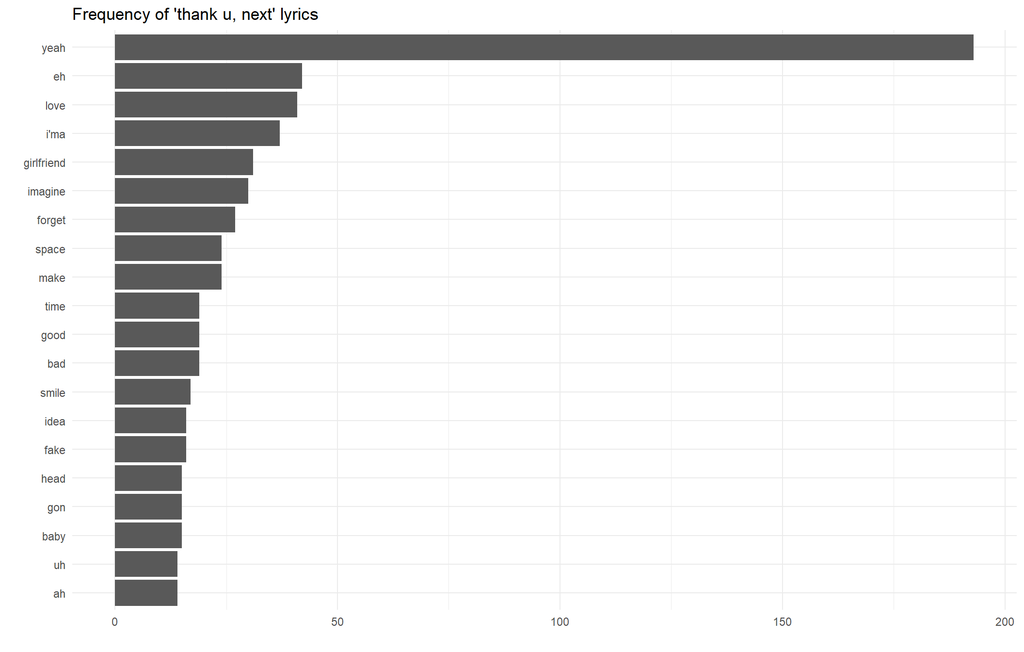

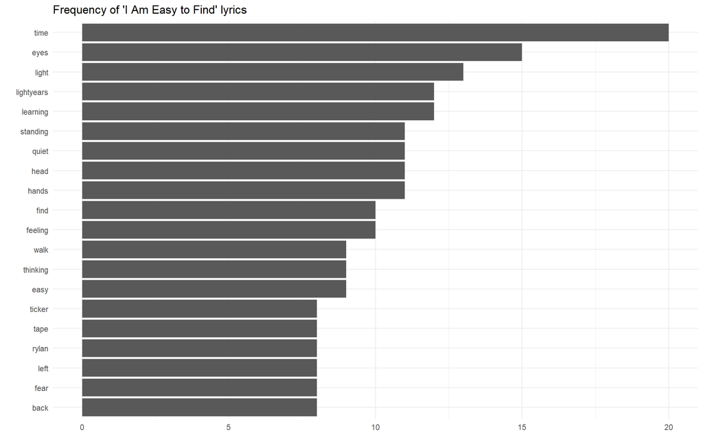

## Sentiment analysis

One way to analyze the sentiment of a text is to consider the text as a combination of its individual words The sentiment content of the whole text is the sum of the sentiments of the individual words The sentiment attached to each word is given by a **lexicon**, which may be downloaded from external sources. Let’s take a look at a few exapmles:

```r
get_sentiments("afinn")
```

```
## # A tibble: 2,477 x 2
##    word       value
##    <chr>      <dbl>
##  1 abandon       -2
##  2 abandoned     -2
##  3 abandons      -2
##  4 abducted      -2
##  5 abduction     -2
##  6 abductions    -2
##  7 abhor         -3
##  8 abhorred      -3
##  9 abhorrent     -3
## 10 abhors        -3
## # ... with 2,467 more rows
```

```r
get_sentiments("bing")
```

```
## # A tibble: 6,786 x 2
##    word        sentiment
##    <chr>       <chr>
##  1 2-faces     negative
##  2 abnormal    negative
##  3 abolish     negative
##  4 abominable  negative
##  5 abominably  negative
##  6 abominate   negative
##  7 abomination negative
##  8 abort       negative
##  9 aborted     negative
## 10 aborts      negative
## # ... with 6,776 more rows
```

```r
get_sentiments("nrc")
```

```
## # A tibble: 13,901 x 2
##    word        sentiment
##    <chr>       <chr>
##  1 abacus      trust
##  2 abandon     fear
##  3 abandon     negative
##  4 abandon     sadness
##  5 abandoned   anger
##  6 abandoned   fear
##  7 abandoned   negative
##  8 abandoned   sadness
##  9 abandonment anger
## 10 abandonment fear
## # ... with 13,891 more rows
```

```r
get_sentiments("loughran")
```

```
## # A tibble: 4,150 x 2
##    word         sentiment
##    <chr>        <chr>
##  1 abandon      negative
##  2 abandoned    negative
##  3 abandoning   negative
##  4 abandonment  negative
##  5 abandonments negative
##  6 abandons     negative
##  7 abdicated    negative
##  8 abdicates    negative
##  9 abdicating   negative
## 10 abdication   negative
## # ... with 4,140 more rows
```

A few words of caution: not every word is in a lexicon! As well, lexicons do not account for qualifiers before a word (e.g., “not happy”) because they were constructed for one-word tokens only. Finally, summing up each word’s sentiment may result in a neutral sentiment, even if there are strong positive and negative sentiments in the body.

Let’s visualize the sentiments in the lyrics between the two groups. What do you notice?

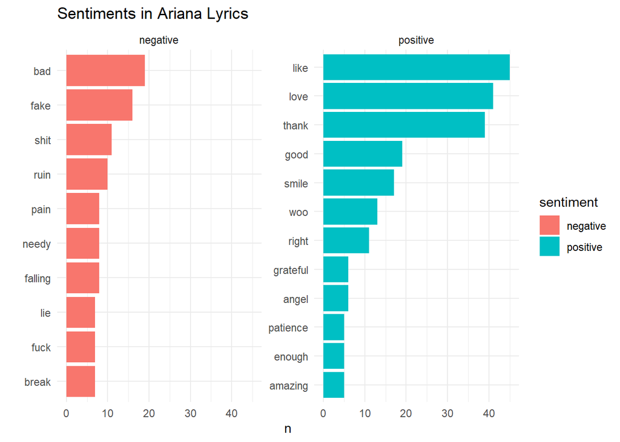

```r
ariana_lyrics %>%
  inner_join(get_sentiments("bing")) %>%
  count(sentiment, word) %>%
  arrange(desc(n)) %>%
  group_by(sentiment) %>%
  top_n(10) %>%
  ungroup() %>%
  ggplot(aes(fct_reorder(word, n), n, fill = sentiment)) +
    geom_col() +
    coord_flip() +
    facet_wrap(~ sentiment, scales = "free_y") +
    theme_minimal() +
    labs(title = "Sentiments in Ariana Lyrics",
         x = "")
```

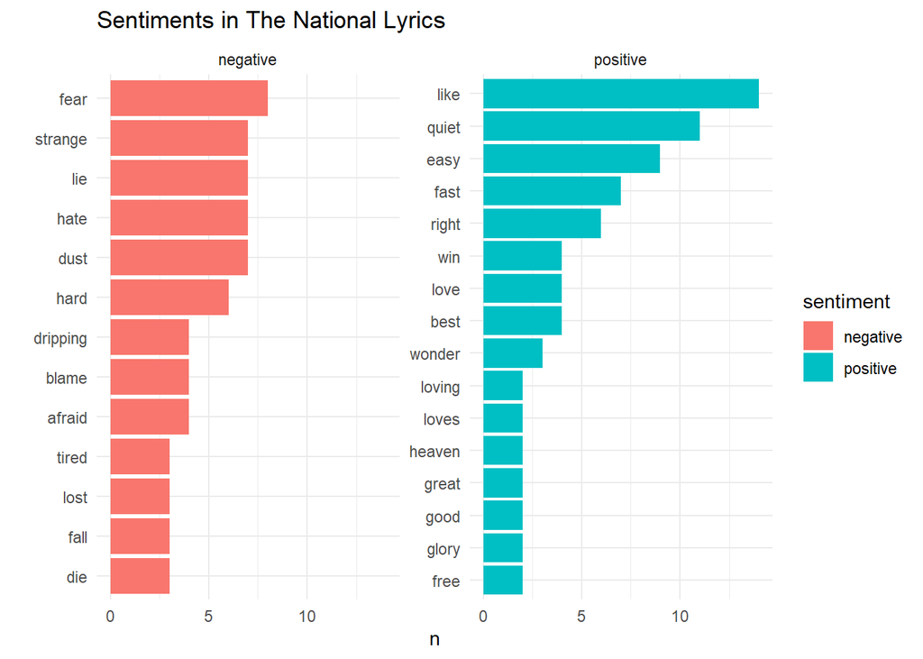

```r
national_lyrics %>%
  inner_join(get_sentiments("bing")) %>%
  count(sentiment, word) %>%
  arrange(desc(n)) %>%
  group_by(sentiment) %>%
  top_n(10) %>%
  ungroup() %>%
  ggplot(aes(fct_reorder(word, n), n, fill = sentiment)) +
    geom_col() +
    coord_flip() +
    facet_wrap(~ sentiment, scales = "free_y") +
    theme_minimal() +
    labs(title = "Sentiments in The National Lyrics",
         x = "")
```

And finally, let’s create a visualization comparing relative frequency between the two artists on their albums:

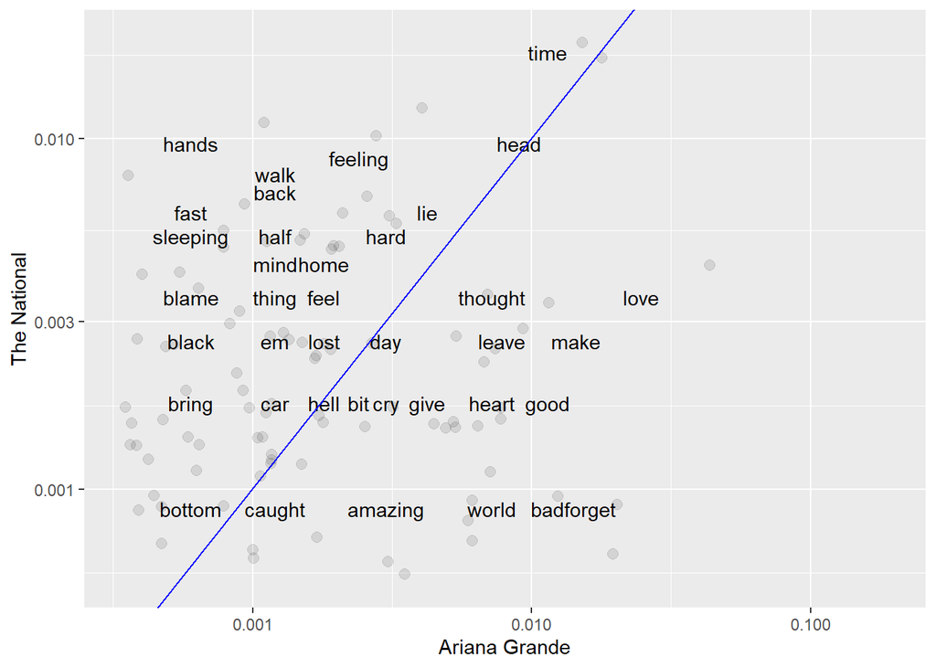

```r
# combine the lyrics, calculate frequencies
combined <- bind_rows(ariana_lyrics, national_lyrics) %>%
  anti_join(get_stopwords(source = "smart")) %>%
  group_by(artist) %>%
  count(word, sort = T) %>%
  mutate(freq = n / sum(n)) %>%
  select(artist, word, freq) %>%
  spread(artist, freq)

# make into nice plot

ggplot(combined, aes(x = `Ariana Grande`, y = `The National`))+
  # hide discreteness
  geom_jitter(alpha = 0.1, size = 2.5, width = 0.25, height = 0.25) +
  geom_text(aes(label = word), check_overlap = T, vjust = 1.5)+
  scale_x_log10()+
  scale_y_log10()+
  geom_abline(color = "blue")
```